# Assignment5

Yuhong Zhao

3/12/2022

## Question: Are towns with more college educated pople more likely to vote for Clinton and Legalization of Marijuana?

We would like to investigate whether if towns in Massachusetts with a higher population percentage of college educated more likely to vote for Clinton and Legalization of Marijuana during the 2016 Election. My hypothesis is that there is a correlation between them, where if a town with a higher percentage of college educated are more likely vote for Clinton and Marijuana.

## Data

To answer our question, we will need data for Massachusetts 2016 voting and referendum results and demographic.

First, we will need importing the necessary libraries and import the csv as a data frame into R. We also imported a map file that contains coordinates for each town, thus we can visualize where the votes are coming from.

```r
# Importing library
library(sf)
library(dplyr)
library(tidyverse)
library(ggplot2)

# Importing 2016 Presidential election result data
election <- read.csv("clinton_trump.csv", stringsAsFactors = FALSE)
head(election)
```

```
##          town candidate  votes
## 1      Boston   Clinton 216754
## 2   Cambridge   Clinton  44835
## 3   Worcester   Clinton  42534
## 4 Springfield   Clinton  38235
## 5      Boston     Trump  37756
## 6      Newton   Clinton  35395
```

```r
# Importing 2016 Referendum result for Marijuana
marijuana <- read.csv("Marijuana.csv", stringsAsFactors = FALSE)
head(marijuana)
```

```
##          town candidate  votes
## 1      Boston       Yes 163724
## 2      Boston        No  98454
## 3   Cambridge       Yes  35360
## 4   Worcester       Yes  35056
## 5  Somerville       Yes  29447
## 6 Springfield       Yes  29366
```

```r
# Importing the demographic data
demog <- read.csv("mass_votes_demog.csv")
head(demog)
```

```
##       town cl_yes_pct charter_yes_pct mj_yes_pct TotalPop    PopDen
## 1 abington  0.5053323       0.3404035  0.5265573    16196 1730.4948
## 2    acton  0.7819807       0.4095451  0.5190114    23209 1192.6498
## 3 acushnet  0.4564460       0.3562256  0.5110783    10414  969.0505
## 4    adams  0.6524209       0.3138631  0.5715000     8266 1149.1213
## 5   agawam  0.4554993       0.3281583  0.4918671    28701 1623.4816
## 6 amesbury  0.6156990       0.3448690  0.5854613    17082 1676.6030
##   MedHouseIncome  PctYoung PctCollege PctFemale  PctWhite
## 1       77131.59 0.4287478  0.3039568 0.5620524 0.9165226
## 2      132892.52 0.3903658  0.7745787 0.4976518 0.7088199
## 3       72966.51 0.3780488  0.2007663 0.5053774 0.9255809
## 4       49682.71 0.3763610  0.2264626 0.5113719 0.9635858
## 5       63476.59 0.3812062  0.2879430 0.5237100 0.8783666
## 6       77041.57 0.3871327  0.4169838 0.5065566 0.9378293
```

```r
#Importing map data for MA towns
map = read.csv("map.csv",stringsAsFactors=F)
head(map)
```

```
##     place      lat     long group
## 1 Newbury 951401.6 256497.2   0.1
## 2 Newbury 951284.0 256497.0   0.1
## 3 Newbury 951152.6 256523.5   0.1
## 4 Newbury 950778.6 256534.1   0.1
## 5 Newbury 950699.9 256547.5   0.1
## 6 Newbury 950562.9 256548.6   0.1
```

## Mapping with GGplot

We can map the percentage of Clinton votes and Marijuana votes to visualize and understand better where the votes are coming from.

First, we will need clean the data before we are able to map it.

```r
# Seperating the different candidate votes to their own column
election <- spread(election, candidate, votes)
marijuana <- spread(marijuana, candidate, votes)

# Make a column with the total votes
election$Total <- election$Clinton + election$Trump + election$Johnson + election$Stein
marijuana$Total <- marijuana$No + marijuana$Yes

# Make a column that contains the percentage
election$Cl_percent <- election$Clinton / election$Total
marijuana$Mj_percent <- marijuana$Yes / marijuana$Total

# Rename our column name so we can join with our map data
election <- rename(election, place = town)
marijuana <- rename(marijuana, place = town)


# Our Clinton votes data after cleaning up
head(election)
```

```
##      place Clinton Johnson Stein Trump Total Cl_percent
## 1 Abington    4075     417   102  3989  8583  0.4747757
## 2    Acton    9096     543   207  2536 12382  0.7346148
## 3 Acushnet    2358     171    85  2808  5422  0.4348949
## 4    Adams    2412     189    80  1285  3966  0.6081694
## 5   Agawam    6208     651   208  7421 14488  0.4284925
## 6   Alford     226       8     8    52   294  0.7687075
```

```r
# Our Marijuana votes data after cleaning up
head(marijuana)
```

```
##      place   No  Yes Total Mj_percent
## 1 Abington 4127 4590  8717  0.5265573
## 2    Acton 6072 6552 12624  0.5190114
## 3 Acushnet 2648 2768  5416  0.5110783
## 4    Adams 1714 2286  4000  0.5715000
## 5   Agawam 7435 7197 14632  0.4918671
## 6   Alford   98  189   287  0.6585366
```

Once our data is done cleaning, we can combine them with our map data. Then we can graph it and see what’s going on.

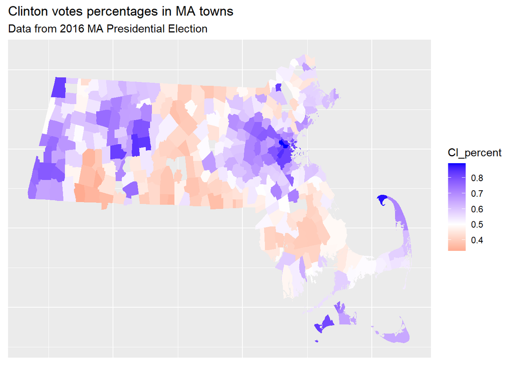

```r
# Joining with map data
electionMap <- election %>% inner_join(map)
mjMap <- marijuana %>% inner_join(map)
# Map of Clinton votes percentage in MA towns
electionMap <- ggplot(electionMap) +
  geom_polygon() +
  aes(x=long,y=lat,fill=Cl_percent,group=group) +
  # Gradient scale color
  scale_fill_gradient2(midpoint=.5,low = "red",high="blue",mid="white") +
  # Remove the X axis labels
  theme(axis.title.x=element_blank(),
        axis.text.x=element_blank(),
        axis.ticks.x=element_blank()) +
  # Remove the Y axis labels
  theme(axis.title.y=element_blank(),
        axis.text.y=element_blank(),
        axis.ticks.y=element_blank()) +
  # Add title and subtitle
  labs(title = "Clinton votes percentages in MA towns",
       subtitle = "Data from 2016 MA Presidential Election")

electionMap
```

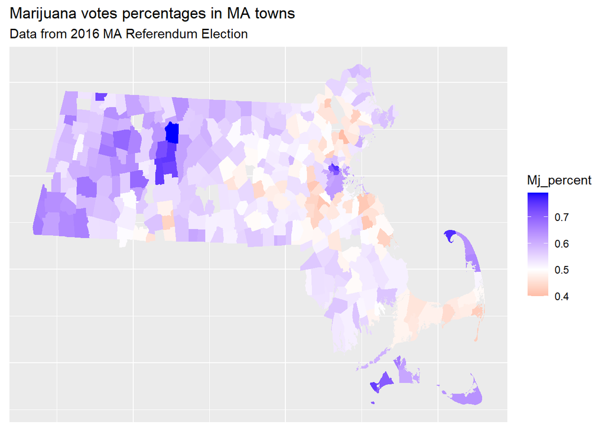

```r
# Map of Marijuana votes percentage in MA towns
mjMap <- ggplot(mjMap) +
  geom_polygon() +
  aes(x=long,y=lat,fill=Mj_percent,group=group) +
  # Gradient Scale Color
  scale_fill_gradient2(midpoint=.5,low = "red",high="blue",mid="white") +
  # Remove the X axis labels
  theme(axis.title.x=element_blank(),
        axis.text.x=element_blank(),
        axis.ticks.x=element_blank()) +
  # Remove the Y axis labels
  theme(axis.title.y=element_blank(),
        axis.text.y=element_blank(),
        axis.ticks.y=element_blank()) +
  # Add title and subtitle
  labs(title = "Marijuana votes percentages in MA towns",
       subtitle = "Data from 2016 MA Referendum Election")

mjMap
```

From the maps above, we can kind of see where majority of the votes are coming from. For Clinton votes, we we can see a more blue shade of color around cities like Amherst and Boston. On the other hand, we can see that western Massachusetts have more votes for Marijuana than eastern Massachusetts. Based on my intuition, the demography of people in western MA have less percentage of college educated people than eastern MA which may contribute to the results above.

## Scatterplot with GGplot

We can plot the data on a plane and try to see any patterns or correlation. First, we can do a scatter plot of the percentage of college educated people against the vote share for “Yes Marijuana” for every town. Then, we can also do the same for the percentage college educated against the vote share for Clinton. With a scatter plot, we will be able to create a line of best fit to understand the correlation.

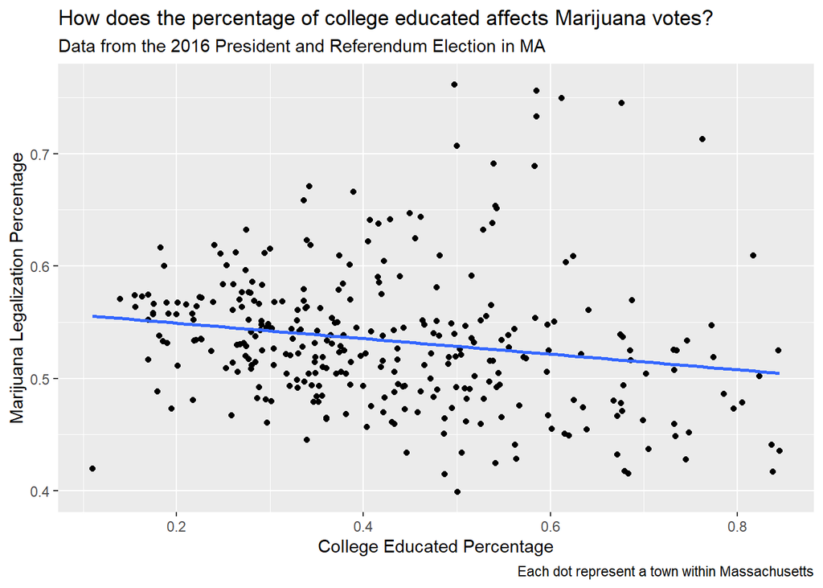

```r
# Percentage College VS Yes Marijuana
marijuanaVSCOllege <- ggplot(demog,
                             aes(x=PctCollege, y=mj_yes_pct)) + geom_point() +
  # Add labels
  labs(
    # x axis label
    x="College Educated Percentage",
    # y axis label
    y="Marijuana Legalization Percentage",
    # title
    title="How does the percentage of college educated affects Marijuana votes?",
    # subtitle
    subtitle = "Data from the 2016 President and Referendum Election in MA",
    # caption
    caption = "Each dot represent a town within Massachusetts") +
  # Add line of best fit
  geom_smooth(method = lm, se = FALSE)

marijuanaVSCOllege
```

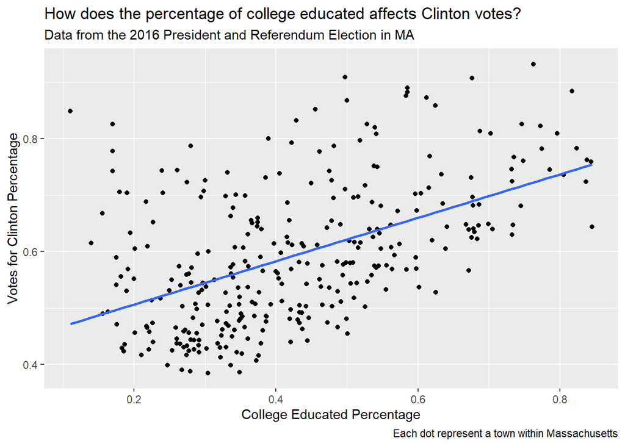

```r
# Percentage College VS Yes Clinton
clintonVSCollege <- ggplot(demog,
                             aes(x=PctCollege, y=cl_yes_pct)) + geom_point() +
  # Add labels
  labs(
    # x axis label
    x="College Educated Percentage",
    # y axis label
    y="Votes for Clinton Percentage",
    # title
    title="How does the percentage of college educated affects Clinton votes?",
    # subtitle
    subtitle = "Data from the 2016 President and Referendum Election in MA",
    # caption
    caption = "Each dot represent a town within Massachusetts") +
  # Add line of best fit
  geom_smooth(method = lm, se = FALSE)

clintonVSCollege
```

## Conclusion

From the two graph above, we can see that there is a correlation between them. It appears that there is a slight negative correlation between Percentage of college educated and percentage of yes votes for marijuana. This means that there is more college educated people, there are less votes for legalization of marijuana. On the other hand, there is a positive correlation between percentage of college educated and percentage of votes for Clinton. As towns with a higher number of college educated people, there are more voters for Clinton. Since Clinton was the presidency candidate for the Democratic Party, there might be a correlation between college educated people and their political parties. However, we will need more data to support that claim.

Comparing the findings with my initial hypothesis, I was half correct. I was correct about the part where as a town has more educated people, it is more likely to vote for Clinton. However, I was wrong about more educated people in town will result in more votes for legalization of marijuana. It showed a negative correlation, opposite of my hypothesis, where less people are voting for legalization of marijuana as there is more college educated people. This is interesting because I expect a lot of people, especially college educated people, to vote for more progressive agenda, and the legalization of marijuana is being pushed by a lot of progressive leaders around the country. I believe to get a better idea, we will need to look at the the age of the voters for marijuana. We can also look at the college educated people broken down by age group as well. I believe that younger people, especially teenagers and young adults more likely to vote for marijuana than their parents.

Since this data is from the 2016 election results and about the State of Massachusetts, it is not representative of the entire country. Massachusetts is one of the most liberal states with the highest percentage of college educated people, therefore it carries a lot of biases. In addition, not all states held referendum election about the legalization of marijuana. To understand the correlations between college educated people and their voting patterns, we will need more data of different elections in the past and data about the entire country.